# The Trends Found During The Spark NorthWest 3G Network Shutdown

## Showing the relationship between the how many customers and how feel about upgrading their device because of the 3G shutdown based on their original device

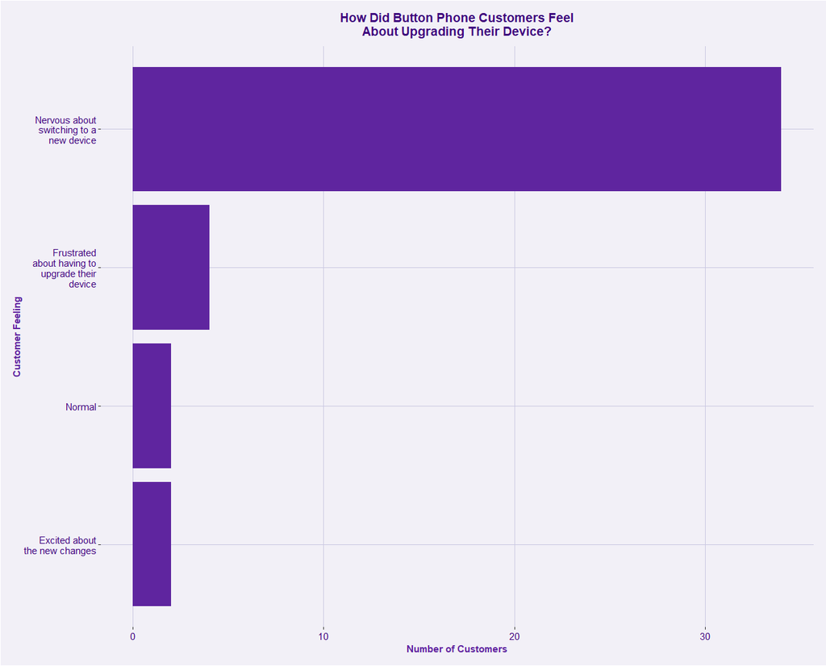

[figure not shown]

The final 2 bar graphs show how our customers were feeling when upgrading their device from 3G to 4G/5G device, most of the customers who were upgrading from a smart phone were nervous as well as a lot of responses being excited about the new changes, some were frustrated, that is understandable as more they probably have spent quite a but of money upgrading to a new device. The other bar plot on the other hand, the people who were upgrading from a button phone, we can confidently say most of the customers were nervous about switching to a device. This is understandable as they are probably not familiar with technology and was very nervous and uncomfortable about making the switch to a new device. Our elderly customers tend to stick to what they know, so switching to something new may most definitely make them nervous about the whole switch.